## Sonora, México Covid19 interactive Map

*Activate Sonora, Mexico, USA or World layer below, to display data accordingly*

[interactive chart not shown]

Source: Own estimation based on Dirección General de Epidemiología, oficial Mexican Government data. World and USA data compiled by Chennai, Tamil Nadu, India. Novel Corona Virus 2019 Dataset.

### Northern Border States

[interactive chart not shown]

Source: Own estimation based on oficial Mexican Government data Dirección General de Epidemiología. Compiled by Gabriel Alfonso Carranco-Sapiéns, Physics Institute of the National Autonomous Univesity of Mexico (UNAM).

The covid19 confirmed cases path for the border states is showing a clear indication of different results of local containment measures for the spread of the virus. While, during the initial outbreak, **Nuevo León** (a state that host Monterrey, the third largest Metropolitan area in the country) had been the main focus of contagion at the border, the pattern dramatically changed by April 5th, when **Baja California** take off.

What kind of measures are working in Nuevo León, a state that appears to have **flatten the curve**, what lessons can be learned from this state´s public health control efforts. And more importantly, what factors are driving Baja California as a rapid growth area.

### The 100th cases threshold.

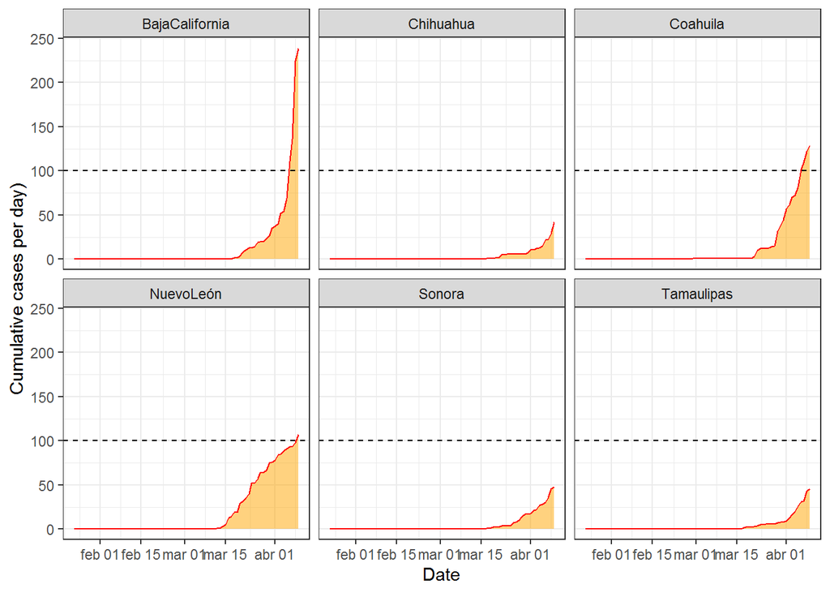

Source: Own estimation based on Dirección General de Epidemiología, oficial Mexican Government data. Data set compiled by Gabriel Alfonso Carranco-Sapiéns, Physics Institute of the National Autonomous Univesity of Mexico (UNAM).

### Are there any significant differences between patient´s age distribution between states?

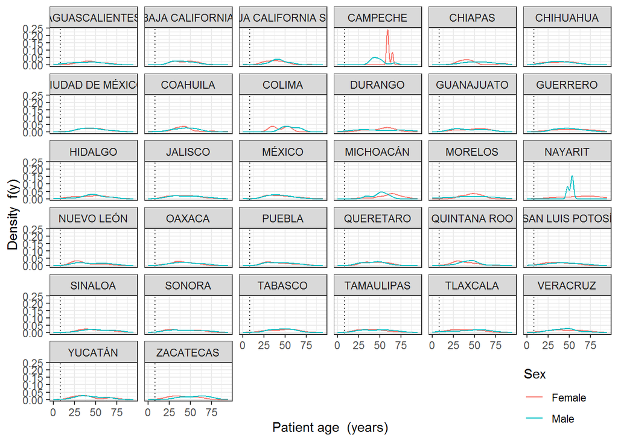

The patient mean age is 45 years old, although no significant diferences across gender are found at this moment 2020-04-08, with an average age of 45 years for the Female population and 46 for Males.

We find that more Males than females are being infected. 1035 Females while 1396 Males are reported since the first case was documented in the country.

Given the highly infectious nature of the virus and the labor market dynamics, a social determinant linked to a greater mobility for males, provides a research area that requires a formal empirical validation.

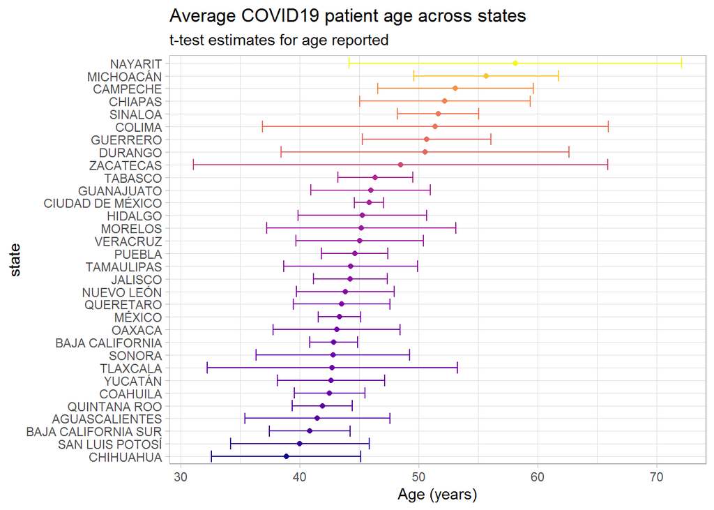